# Case Study 1 - Cyclistic Marketing

Salimah Ismail

2023-10-12

# Case Study 1: How Does a Bike-Share Navigate Speedy Success?

Cyclistic is a fictional bike-share company in Chicago who has several pricing plans: single ride passes, full-day passes and annual memberships. Customers who purchase single rides or full-day passes are considered casual members, whereas those who have annual memberships are considered Cyclistic members.

## The Task

Cyclistic believes that there is a growth opportunity in converting casual riders into full Cyclistic members. This analysis aims to determine **the main differences between how casual members use Cyclistic versus annual members** so that the Cyclistic marketing department can understand these differences and market annual memberships to these casual customers effectively.

## The Data

Cyclistic data sets for analysis are available [here](https://divvy-tripdata.s3.amazonaws.com/index.html), mainly organized as one file per month. I chose to examine one year of data, from July 2022 - 2023 to get the most recent insights on riders.

### Available Information

The data sets include information such as: - Electric vs. Classic Bike - Start and End times of the rides - Starting and Ending locations (station, latitude, longitude) - Membership Type

### Limitations

- We cannot attach the different trips to members beyond their membership type. Therefore, we cannot tell how frequently an individual rider is utilizing the service. It would have been great to be able to look at how frequently a casual member uses the service compared to an annual member.
- There are many instances where station information is missing. However, starting latitudes and longitudes are available, so we can determine distance traveled based on those calculations.

## Method

**1. The data sets were combined into one CSV file.**

**2. Some additional columns were added to the data frame including:** - Ride length, by calculating the difference between the start and end time - Day of the week the ride occurred - Month that the ride occurred - Ride distance, by calculating the difference between the starting and ending latitude and longitudes.

**3. Some rides that had errors in it were discarded, such as ones with negative times travelled even though the distance was significant.***

**4. Summary statistics were calculated and relevant obeservations grouped by Casual and Annual members were visualized such as:**

*Ride Length Comparisons*

```
## Defaulting to continuous.
```

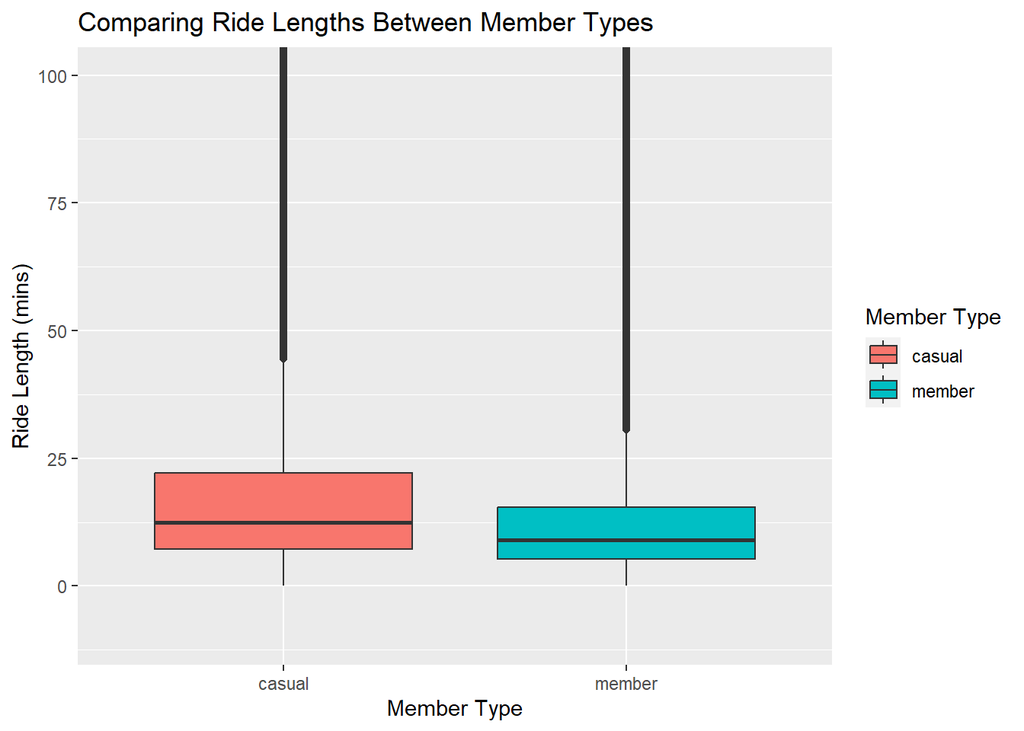

*Distance Comparisons*

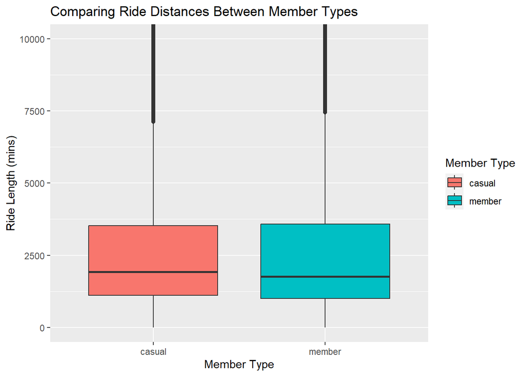

*Bike Type Usage comparisons:*

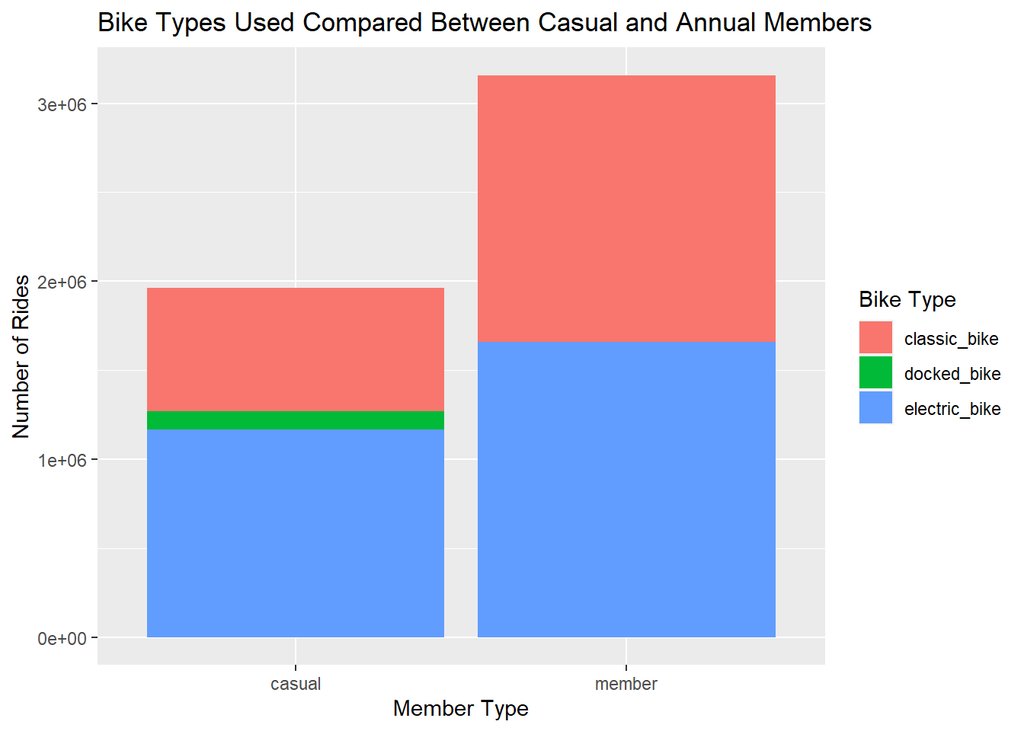

*Bike Day Usage comparisons:*

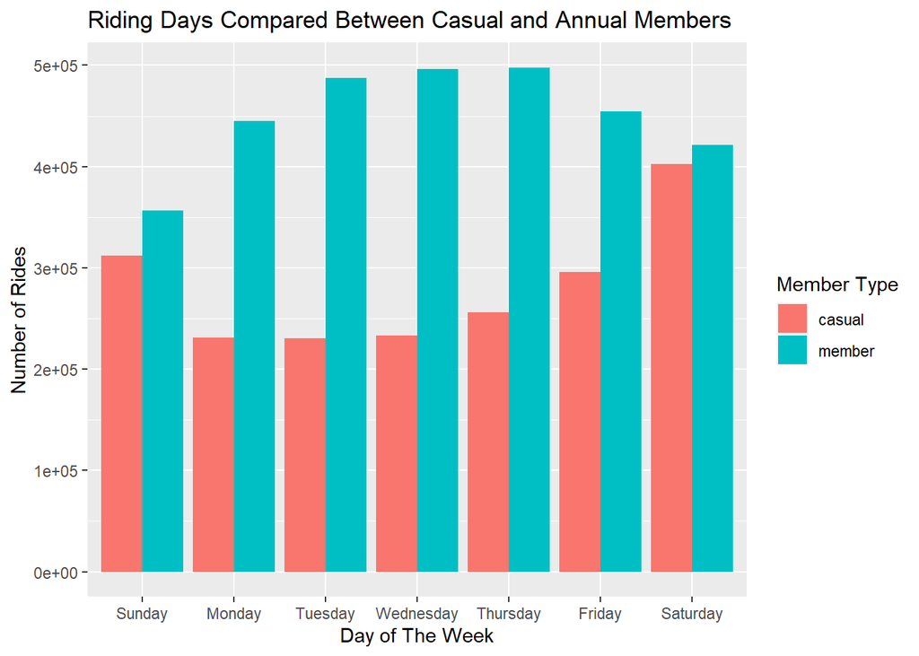

## Conclusions

- Casual Members, on average, seem to use the bikes for *longer periods of time* than Annual Members.
- Casual Members, on average, seem to travel about the *same* distance as Annual members.
- Casual Members seem to *prefer electric bikes* proportionally more than Annual Members.
- Casual Members tend to use the service *in high volumes on weekends* as compared to Annual Members whose higher usage occur on weekdays.